# Distributed Server Project

Matthew Angle, Josh Wood

# Overview

The purpose of this project was to learn how to use CORBA to set up a distributed system across servers and measure the difference in transfer time from one server to another. The tools we used for this experiment were provided but included a Java implemented server and client. CORBA stands for “Common Object Request Broker Architecture”, CORBA provides “vendor-independent architecture and infrastructure that computer applications use to work together over networks”.[1] The Java program we were provided requires us to first setup a ORBD Daemon which the Java program will then use to establish a connection between the server and the client.

# Experiment Conditions

Clipper is a server located at Shippensburg University. Clipper is an Ubuntu 18.04.4 server with Linux Kernel 4.15.0-88-generic, it has an Intel Xeon 2680 v3 and has 20 CPU cores and 24 GB’s of ram, which have been assigned to the virtual machine running Clipper. The ORBD daemon was started on CLipper and our team used ports 1054 and 1055. Java 8 was used to build and run the server and the client.

The German server is a remote virtual server hosted in Germany and uses an Intel Xeon e5-2660 v4 but is assigned one virtual core and 1 GB of ram. The server runs Ubuntu 18.04.5 with Linux Kernel 4.15.0-122-generic x86_64. The ORBD daemon was started on CLipper and our team used ports 1054 and 1055. Java 8 was used to build and run the server and the client.

The Spanish server is also a remote virtual server hosted in Spain instead of Germany. It uses an Intel Xeon E5-2683 v3 but is also assigned one virtual core and 1 GB of ram. The server runs Ubuntu 18.04.5 with Linux Kernel 4.15.0-122-generic x86_64. The ORBD daemon was started on CLipperand our team used ports 1054 and 1055. Java 8 was used to build and run the server and the client.

# First Experiment

We initially set up our experiment using a bash script that would start and stop the ORBD Daemon and the Java Server, then run the client and measure the time the client took to complete the file transfer. In our experiment we used a text document full of random characters that was 1 Mb in size, we stored that on our server in the appropriate folder in the Java Server build path and then transferred that file to our client. We ran this bash script 1000 times on the German server and the Spanish server and stored the results in a csv.

# First Results

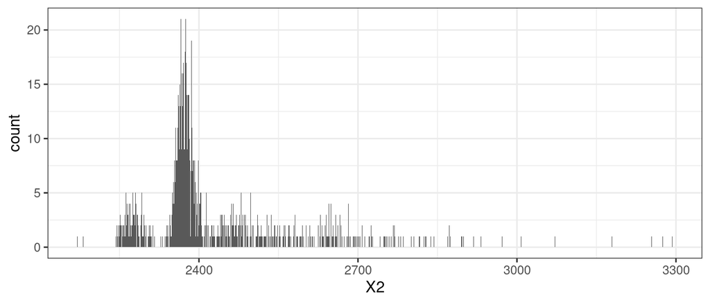

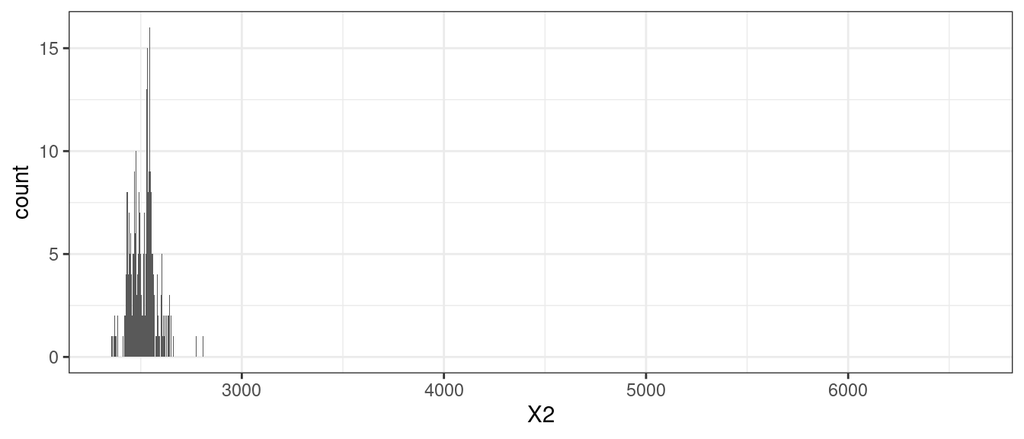

# Second Experiment

After some consideration we became concerned that the differences in compile time on the each server may have influenced our results and rendered them void.

We set up a second experiment where we transferred in the same manner a 2 MB text file, but instead of measuring total time to compile and transfer we only measured the time that it took to transfer using a Java method to measure the start and stop time of the transfer file method. We nested this method in a loop and ran it 1000 times on Clipper, the German and the Spanish server. We ran these tests 3 times each for each server and stored the results in corresponding csv files. The Clipper test was ran as a baseline to see best case scenarios for the transfer. The file size chose was intended to be large enough to be significant but not too large to be overwhelming for the remote servers. The number of times we ran the test was to ensure we could have a large enough sample size to make significant analysis.

# Clipper Java Results

We started analysis by looking at a point plot of the data over time.

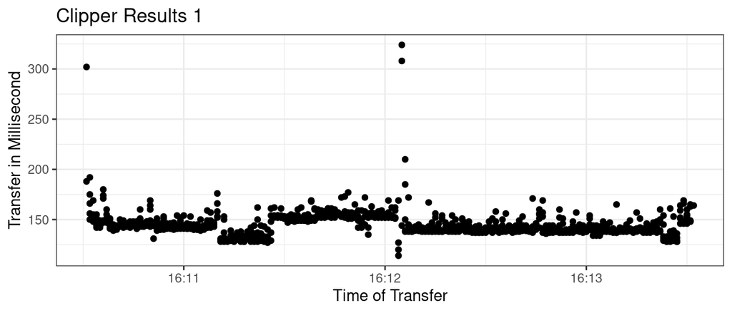

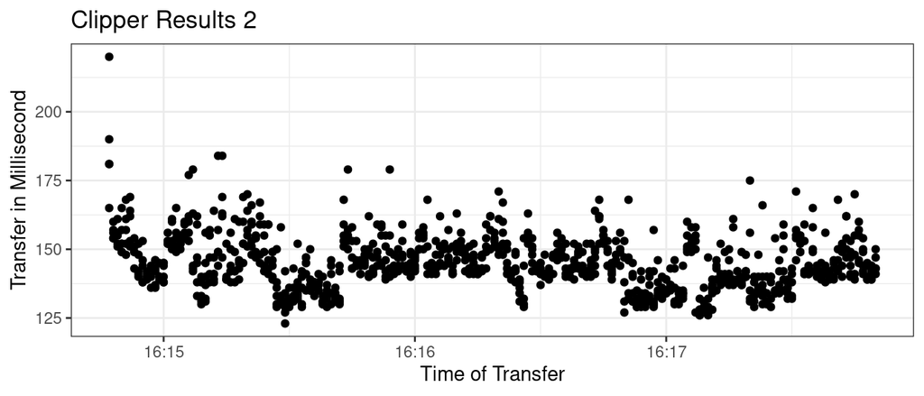

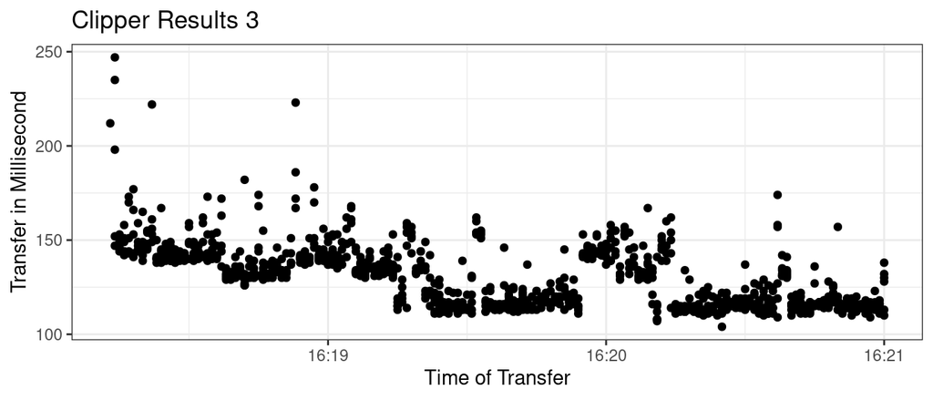

The time series data seems to show a mostly flat line across the first two tests with a few outliers except for the third plot which seems to stepped into two separate lines. To get a better look at these and to see if the data was normally distributed we made histograms using the data.

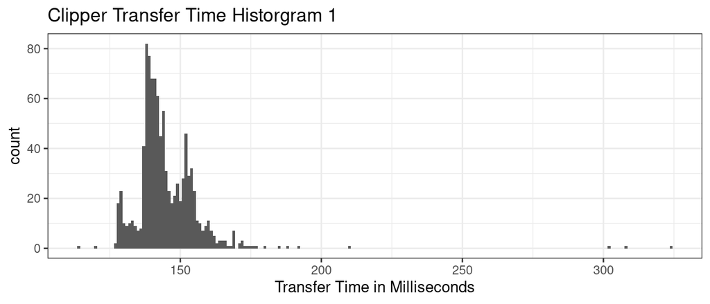

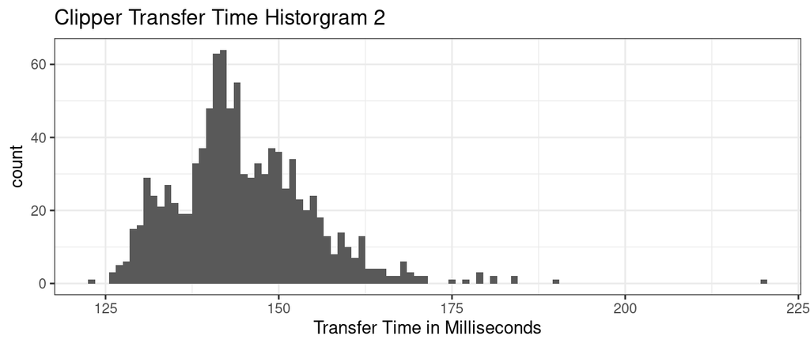

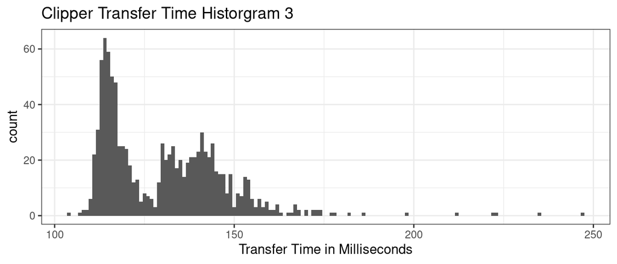

It became evident that we did have a few outliers and likely a bimodal distribution in the third set of data. To account for the outliers we used the boxplot function contained in the ggstatsplot package to remove outliers and clean up the data. The boxplot function can be used to identify outliers “which lie beyond the extremes of the whiskers”. [2] After transforming the data the following were our resulting histograms.

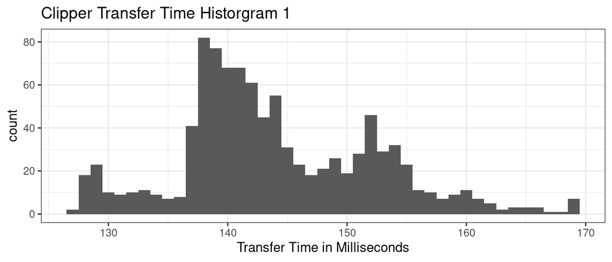

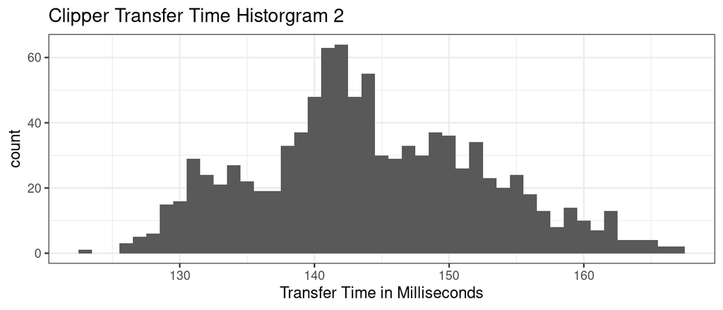

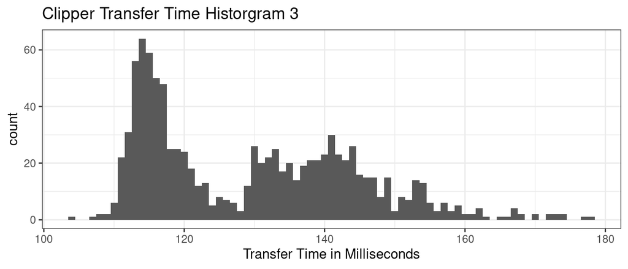

As can be seen in the resulting histograms the second test on Clipper seems to approach a normal distribution. The first and third test both seem to be bimodal.

```r
mean(javaResults01$X2)
```

```
## [1] 144.973
```

```r
mean(javaResults02$X2)
```

```
## [1] 144.859
```

```r
mean(javaResults03$X2)
```

```
## [1] 130.115
```

# German Server Results

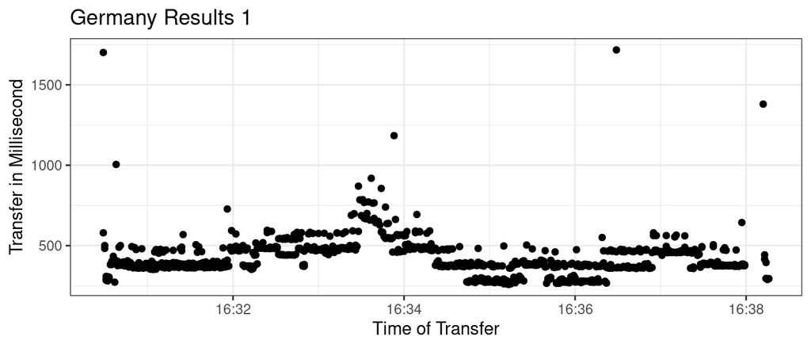

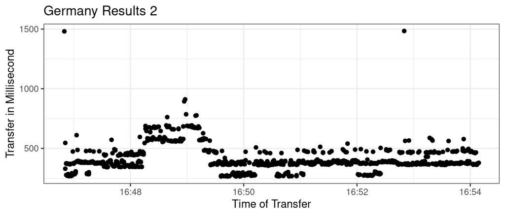

[figure not shown]

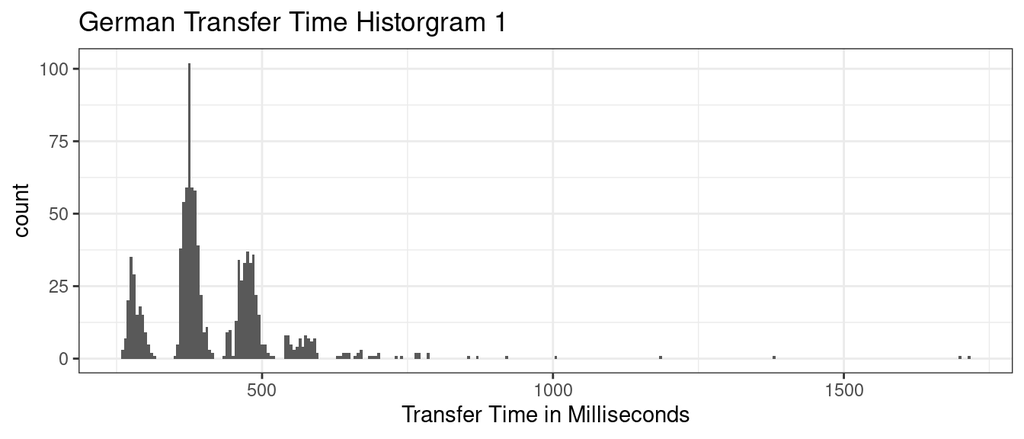

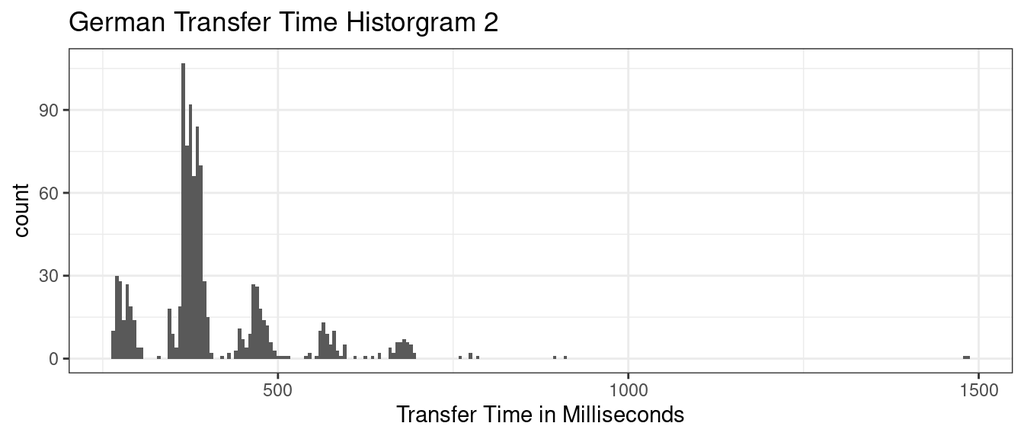

[figure not shown]

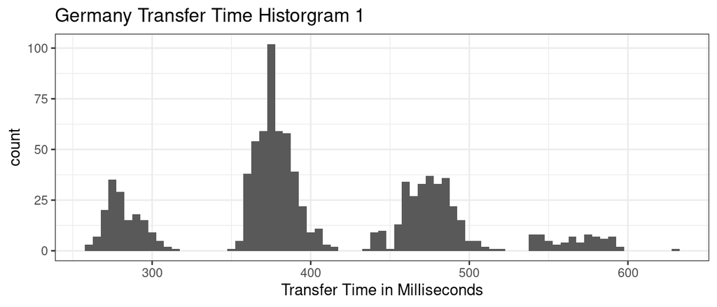

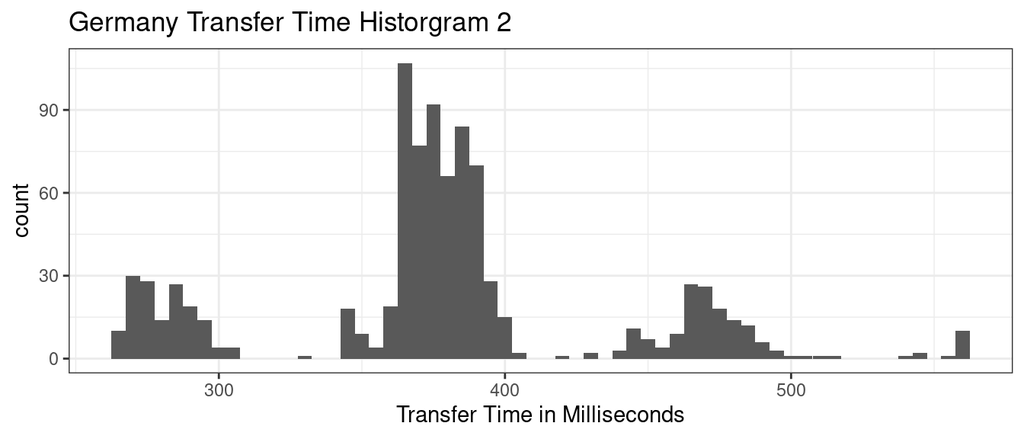

[figure not shown]